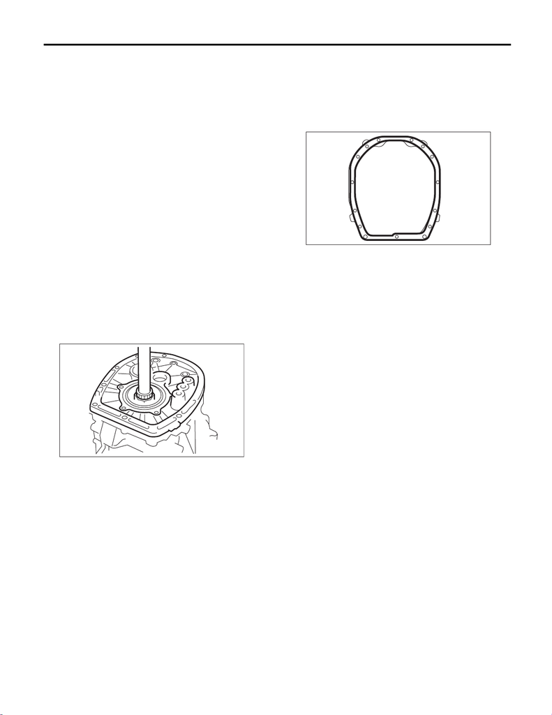

6MT(TY85)-92

Drive Pinion Shaft Assembly

MANUAL TRANSMISSION AND DIFFERENTIAL

22.Drive Pinion Shaft Assembly

A: REMOVAL

1) Remove the manual transmission assembly

from the vehicle. <Ref. to 6MT(TY85)-31, REMOV-

AL, Manual Transmission Assembly.>

2) Prepare the transmission for overhaul. <Ref. to

6MT(TY85)-38, Preparation for Overhaul.>

3) Remove the neutral position switch, back-up

light switch and harness. <Ref. to 6MT(TY85)-41,

REMOVAL, Neutral Position Switch.> <Ref. to

6MT(TY85)-40, REMOVAL, Back-up Light

Switch.>

4) Remove the extension case. <Ref. to

6MT(TY85)-42, REMOVAL, Extension Case.>

5) Remove the transfer driven gear. <Ref. to

6MT(TY85)-54, REMOVAL, Transfer Driven

Gear.>

6) Remove the center differential. <Ref. to

6MT(TY85)-56, REMOVAL, Center Differential.>

7) Remove the transmission case. <Ref. to

6MT(TY85)-57, REMOVAL, Transmission Case.>

8) Remove the individual gear assemblies. <Ref. to

6MT(TY85)-63, REMOVAL, Main Shaft Assem-

bly.>

9) Remove the drive pinion shaft assembly.

B: INSTALLATION

1) Remove any remaining gasket material from the

drive plate and clutch housing.

2) Apply liquid gasket to the clutch housing.

Liquid gasket:

THREE BOND 1215B or equivalent

3) Install the individual gear assemblies. <Ref. to

6MT(TY85)-64, INSTALLATION, Main Shaft As-

sembly.>

4) Install the transmission case. <Ref. to

6MT(TY85)-59, INSTALLATION, Transmission

Case.>

5) Install the center differential. <Ref. to

6MT(TY85)-56, INSTALLATION, Center Differen-

tial.>

6) Install the transfer driven gear. <Ref. to

6MT(TY85)-54, INSTALLATION, Transfer Driven

Gear.>

7) Install the extension case. <Ref. to 6MT(TY85)-

42, INSTALLATION, Extension Case.>

8) Install the neutral position switch, back-up light

switch and harness. <Ref. to 6MT(TY85)-41, IN-

STALLATION, Neutral Position Switch.> <Ref. to

6MT(TY85)-40, INSTALLATION, Back-up Light

Switch.>

9) Install the manual transmission assembly to the

vehicle. <Ref. to 6MT(TY85)-33, INSTALLATION,

Manual Transmission Assembly.>

MT-00640

MT-00532

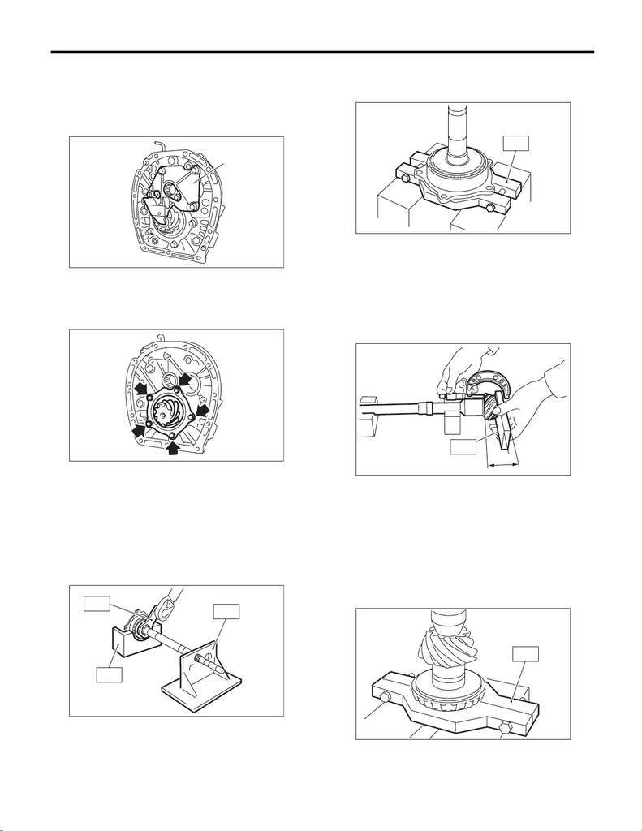

6MT(TY85)-93

Drive Pinion Shaft Assembly

MANUAL TRANSMISSION AND DIFFERENTIAL

C: DISASSEMBLY

NOTE:

Replace the drive pinion shaft and hypoid driven

gear as a set.

1) Remove the oil guide A.

2) Remove the drive pinion shaft and shim from the

adapter plate.

3) Affix the ST to the work table.

ST 18664AA000 BASE

4) Flatten the tab of the lock nut.

5) Attach ST3 to the lock nut, and set the drive pin-

ion shaft to ST. Remove the lock nut and lock

washer.

ST1 18667AA000 HOLDER

ST2 18664AA000 BASE

ST3 18621AA000 ADAPTER WRENCH

6) Using the ST, remove the double taper roller

bearing assembly.

ST 18723AA000 REMOVER

D: ASSEMBLY

1) Using the ST, measure drive pinion measure-

ment A.

NOTE:

When selecting the drive pinion shim, refer to mea-

surement A.

ST 398643600 GAUGE

2) Using the ST and a press, attach the double

taper roller bearing inner race (front side) to the

drive pinion shaft.

ST 18723AA000 REMOVER

CAUTION:

NOTE:

Use a new double taper roller bearing.

(A) Oil guide A

MT-01624

(A)

MT-00642

MT-00643

ST2

ST3

ST1

ST

MT-00644

MT-00645

A

ST

MT-00646

ST

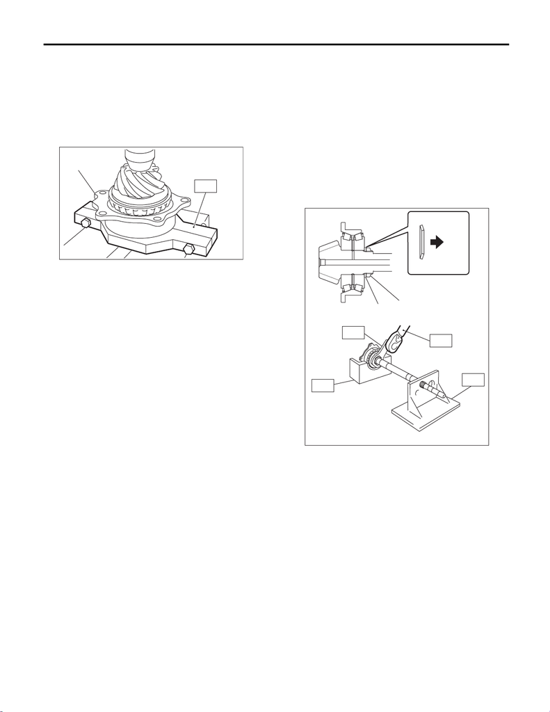

6MT(TY85)-94

Drive Pinion Shaft Assembly

MANUAL TRANSMISSION AND DIFFERENTIAL

3) Using the ST and a press, attach the double

taper bearing outer race and the double taper roller

bearing to the drive pinion shaft.

ST 18723AA000 REMOVER

NOTE:

• Use a new double taper roller bearing.

• Push in to a position where the bearing rotates

smoothly.

4) Attach a new lock washer and a new lock nut.

5) Set the ST to the drive pinion, and tighten the

lock nut.

ST1 18667AA000 HOLDER

ST2 18664AA000 BASE

ST3 18621AA000 ADAPTER WRENCH

ST4 18852AA000 TORQUE WRENCH

NOTE:

• Tighten using the ST and the straight line torque

wrench.

• Make sure the lock washer is installed in the

proper direction.

Tightening torque:

265 N·m (27.0 kgf-m, 195.4 ft-lb)

(A) Double taper roller bearing outer race

MT-00647

(A)

ST

(A) Lock washer

(B) Lock nut

(C) Nut side

MT-02715

(B)

(A)

(C)

ST2

ST4

ST3

ST1

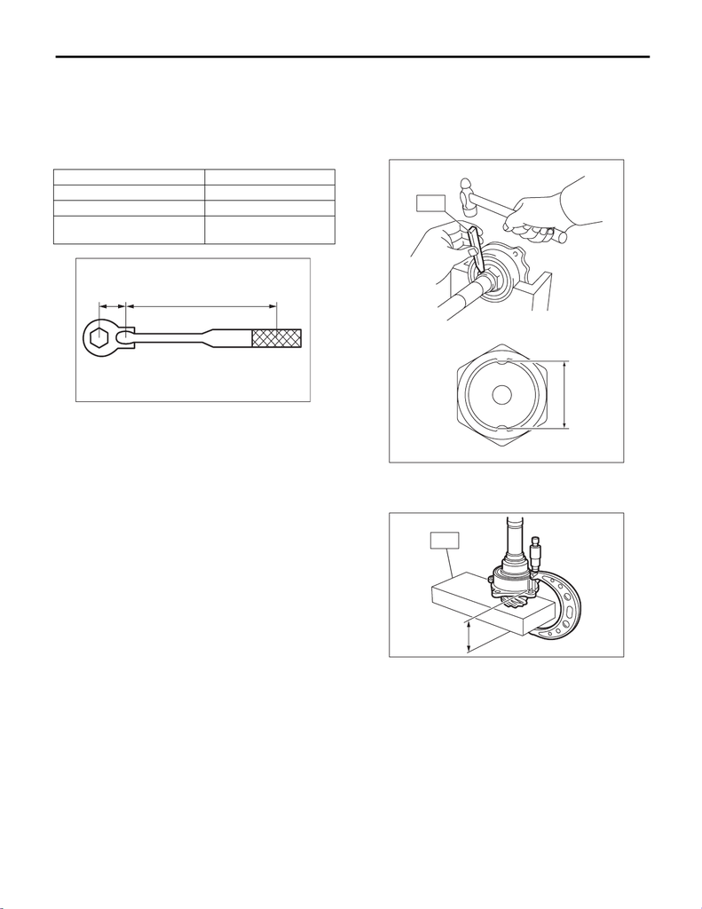

6MT(TY85)-95

Drive Pinion Shaft Assembly

MANUAL TRANSMISSION AND DIFFERENTIAL

NOTE:

the calculation below to calculate and tighten the

lock nut.

Tighten using the ST and the straight line torque

wrench.

6) Measure the starting torque. <Ref. to

6MT(TY85)-96, INSPECTION, Drive Pinion Shaft

Assembly.>

7) Using the ST, crimp the lock nut in 2 locations,

with dimensions within A 37±0.5 mm (1.46±0.02

in).

ST 18670AA000 PUNCH

NOTE:

Do not damage the crimp area of the lock nut.

8) Using the ST, measure drive pinion measure-

ment B.

ST 398643600 GAUGE

T N·m (kgf-m, ft-lb) Torque wrench setting

L1 m (in) Torque wrench length

0.1 m (3.94 in) Length of ST

(A) 0.1 m (3.94 in)

MT-00614

(A)

L1

MT-00649

A

ST

MT-00650

B

ST

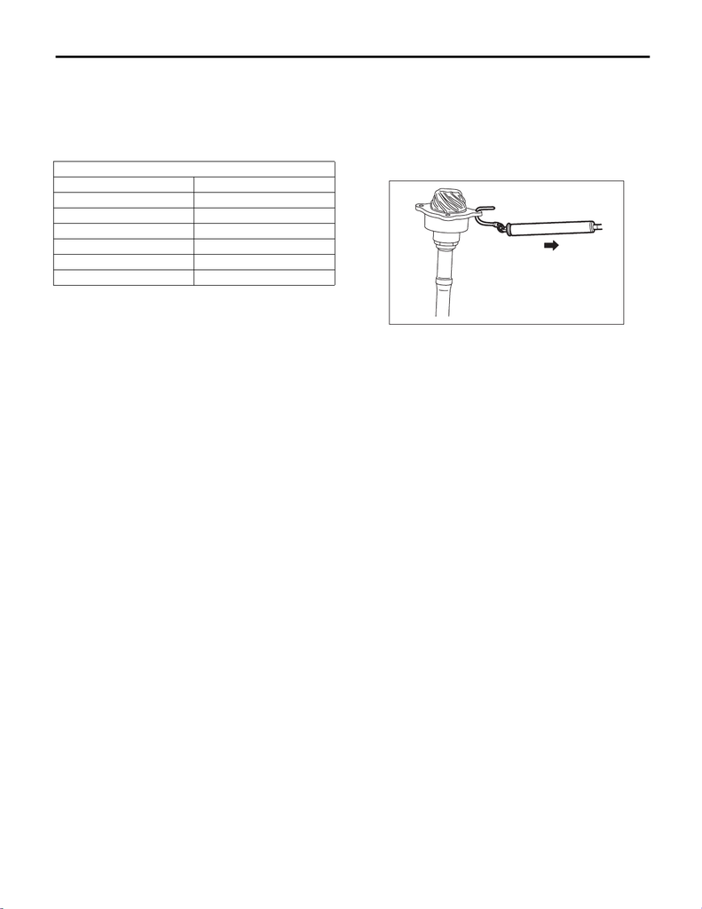

6MT(TY85)-96

Drive Pinion Shaft Assembly

MANUAL TRANSMISSION AND DIFFERENTIAL

9) Calculate from the calculation below to select 1

or 2 drive pinion shims from the following table.

6.5±0.0625 mm – (B – A) [0.26±0.0025 in – (B – A)]

NOTE:

A: Measurement value in step 1)

B: Measurement value in step 8)

10) Apply transmission gear oil to the side face of

the double taper roller bearing, and attach the drive

pinion shaft and the selected shims to the adapter

plate.

Tightening torque:

54 N·m (5.5 kgf-m, 39.8 ft-lb)

11) Install the oil guide A.

Tightening torque:

18 N·m (1.8 kgf-m, 13.3 ft-lb)

E: INSPECTION

1) Using a spring scale, measure the starting

torque. If the starting torque is outside the specifi-

cation range, replace the double taper roller bear-

ing.

Starting torque:

0 — 0.95 N (0 — 0.097 kgf, 0 — 0.21 lbf)

2) Gear

Replace gears in the following cases.

• The gear teeth surface is damaged or excessive-

ly worn.

3) Bearing

Replace the bearings in the following cases.

• Wear, rusting or damage of the bearings

• The bearing does not rotate smoothly or an ab-

normal noise is emitted when turning.

4) Adapter plate

Replace the adapter plate in the following cases:

• Wear, rusting or damage of the bearings

• Damage of the adapter plate

5) Check that the pipes and pipe chambers are not

damaged or clogged. Repair or replace if damaged

or clogged.

Drive pinion shim

Part No. Thickness mm (in)

32295AA270 0.15 (0.0059)

32295AA280 0.175 (0.0069)

32295AA290 0.20 (0.0079)

32295AA300 0.225 (0.0089)

32295AA310 0.25 (0.0098)

32295AA320 0.275 (0.0108)

MT-00651

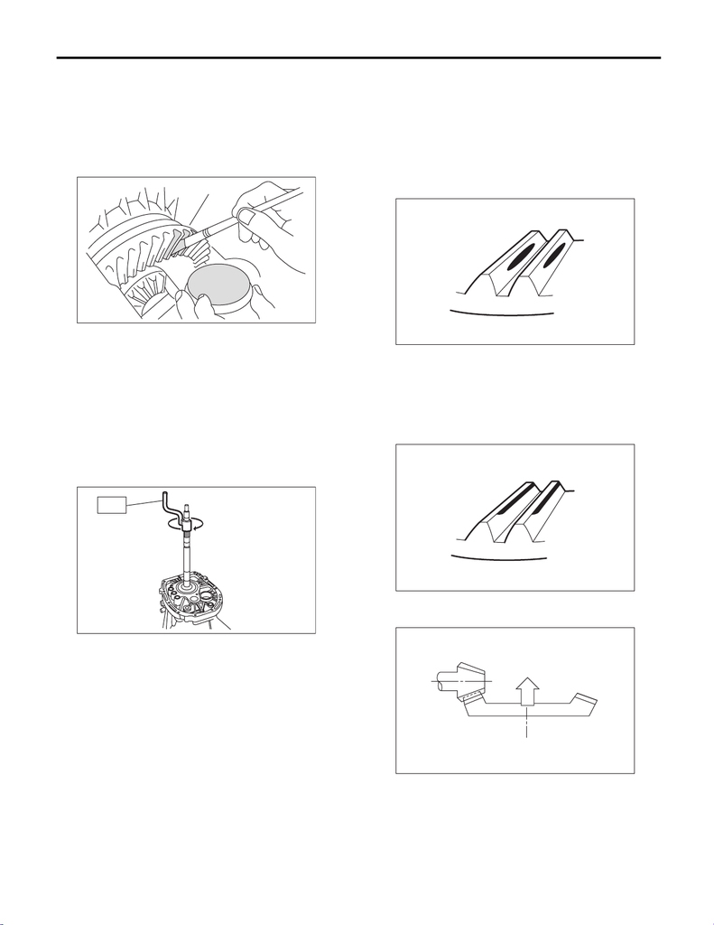

6MT(TY85)-97

Drive Pinion Shaft Assembly

MANUAL TRANSMISSION AND DIFFERENTIAL

F: ADJUSTMENT

1) Inspect and adjust the hypoid driven gear-to-

drive pinion backlash. <Ref. to 6MT(TY85)-103,

HYPOID GEAR BACKLASH, ADJUSTMENT,

Front Differential Assembly.>

2) Apply a thin uniform coat of lead-free red dye on

the surfaces of 3 or 4 hypoid driven gear teeth.

3) Install the drive pinion shaft assembly to the

clutch housing, and tighten at least 4 bolts.

NOTE:

Install with the remaining liquid gasket, so that the

clutch housing and the adapter plate will not be

damaged.

Tightening torque:

50 N·m (5.1 kgf-m, 36.9 ft-lb)

4) Turn a few times using the ST.

ST 18631AA000 HANDLE

5) Remove the drive pinion shaft assembly, and in-

spect the mating condition of the teeth. If the tooth

contact is not correct, adjust the backlash or shim

thickness.

• Correct tooth contact

Check item: Tooth contact surface is slightly

shifted toward the toe side under a no-load con-

dition. (When driving, it moves towards the heel

side.)

• Face contact

Check item: Backlash is too large.

Contact pattern

Corrective action: Tighten the side retainer to move

the driven gear closer to the drive pinion shaft.

MT-00652

MT-00653

ST

(A) Toe side

(B) Heel side

(A)

(B)

MT-01401

AT-00208

AT-01253

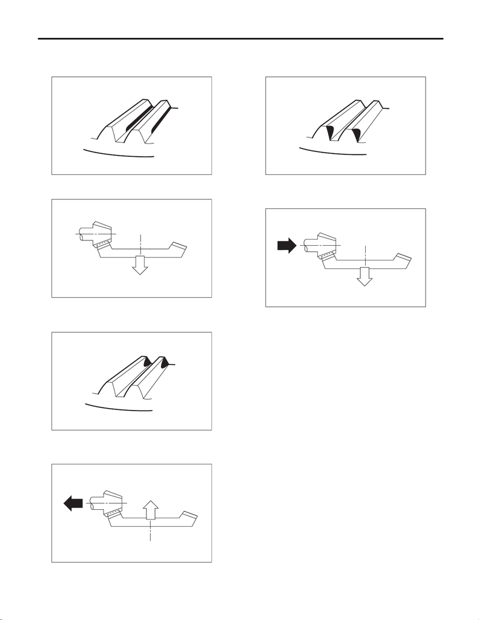

6MT(TY85)-98

Drive Pinion Shaft Assembly

MANUAL TRANSMISSION AND DIFFERENTIAL

• Flank contact

Check item: Backlash is too small.

Contact pattern

Corrective action: Loosen the side retainer to move

the driven gear away from the drive pinion shaft.

• Toe contact (inside contact)

Check item: Teeth contact area is too small.

Contact pattern

Adjustment: Reduce the thickness of the drive pin-

ion shim according to the procedure for moving the

drive pinion away from the driven gear.

• Heel contact (outside end contact)

Check item: Teeth contact area is too small.

Contact pattern

Adjustment: Increase thickness of the drive pinion

shim according to the procedures for moving the

drive pinion closer to the driven gear.

AT-00209

AT-01254

AT-00210

AT-00213

AT-00211

AT-00212